# Creating datasets for data analysis using the nba_api.

### Abstract.

The present notebook showcases the capabilities of the nba_api and the steps to create datasets from it.

### Introduction.

One of the most repeated ideas related to data analysis is that the quality of the data is one of the most important, if not the most important, aspects to make a reliable analysis. Nowadays the sources to obtain information and data are numerous and related to many different fields, however this doesn’t mean that those sources produce high-quality data or that the produced data doesn’t require cleaning or formatting.

For anyone interested in data analysis or working with data in general, practicing the skills of extraction, cleaning, transforming and formatting is valuable and useful. These skills could be overlooked over other skills like: analysis, visualization, story telling and so on. Nevertheless to get high-quality and reliable data the former are paramount.

The purpose of this notebook is to be used as a tutorial to precisely put into practice the extraction, and transformation of data that was retrieved from an API. It will contain multiple explanations and demonstrations regarding the process to obtain the data and some examples of the obstacles that could arise and how to avoid them or work around them. And the Pandas library will be useful for this purpose.

The data that will be used is related to sports, specifically to basketball. Sports have used stats for a long time and yet is one of the fields that has felt the influence of data analysis immediately, even changing the approach to how a sport could be played. An example of this is the increased value the three-point shot has gained and the fact that the middle range two-point shot has been deprecated.

For this notebook data related to a basketball player will be retrieved and prepared for data analysis.

**Disclaimer**: This notebook is not going to provide a modular code to retrieve, clean and format the data but rather it is a tutorial to introduce the basics of using the API to extract data and also the basics to manipulate and work with the retrieved data in order to make it useful and reliable for data analysis. However some tweaks and modifications could make the code modular and ready to be used for a more work-oriented project.

### Installing the API and importing the necessary libraries.

The installation of the API is straightfoward as well as the import of the libraries.

There is only one configuration neccesary for the pandas library and that is setting the `pd.options.mode.copy_on_write` to `True`. This configuration is to avoid the complication and confusion that arises when working with pandas dataframes. Specifically, the uncertainty if working with a dataframe alters the dataframe itself or creates a copy of that dataframe and leaves the original intact.

Setting it to `True` ensures that a copy of a dataframe will be created when working with it and leave the original intact. This functionality is already applied in the latest version of Pandas, however in case an older version is used this comes in handy.

```python
pip install nba_api
```

```python
import numpy as np
import pandas as pd
import requests
import time

pd.options.mode.copy_on_write = True
```

The first step is finding and getting the information of the player. The API’s endpoints usually require certain arguments; when looking for data about a specific player, having the player’s information, specially his ID, will be very useful to use in the arguments of the endpoints and get the desired information.

It is necessary to create an object of the endpoint that will be used to retrieve the information. After that there are methods that will work with the API to get the specific information in different formats.

The `nba_api` contains the list of methods and the arguments required when creating the object for each endpoint.

Stephen Curry will be the player used, so it is necessary to find his basic information in the API, for that the static endpoint players will be used. In this case, static means that the `nba_api` library will not make a call or connection with the actual application because the library already contains the information required.

```python
from nba_api.stats.static import players
curry = players.find_players_by_full_name('Stephen curry') # The object for that specific endpoint is created
curry_id = curry[0]["id"] #The ID of the player is saved for later.

curry #This will display the basic information when the method find_players_by_full_name is called
```

```
[{'id': 201939,
  'full_name': 'Stephen Curry',
  'first_name': 'Stephen',
  'last_name': 'Curry',
  'is_active': True}]
```

Having the player’s ID a call to the API is made to get the player’s profile. It will return general information about the player like: his name, school, if he is active, etc.

```python
from nba_api.stats.endpoints import commonplayerinfo
curry_profile = commonplayerinfo.CommonPlayerInfo(player_id = curry_id) # The object for that specific endpoint is created
curry_profile.common_player_info.get_data_frame() # A method to retrieve the information in Pandas dataframe format.

#The API can also retrieve the information in JSON or as a dictionary.
```

|  | PERSON_ID | FIRST_NAME | LAST_NAME | DISPLAY_FIRST_LAST | DISPLAY_LAST_COMMA_FIRST | DISPLAY_FI_LAST | PLAYER_SLUG | BIRTHDATE | SCHOOL | COUNTRY | ... | PLAYERCODE | FROM_YEAR | TO_YEAR | DLEAGUE_FLAG | NBA_FLAG | GAMES_PLAYED_FLAG | DRAFT_YEAR | DRAFT_ROUND | DRAFT_NUMBER | GREATEST_75_FLAG |
| --- | --- | --- | --- | --- | --- | --- | --- | --- | --- | --- | --- | --- | --- | --- | --- | --- | --- | --- | --- | --- | --- |
| 0 | 201939 | Stephen | Curry | Stephen Curry | Curry, Stephen | S. Curry | stephen-curry | 1988-03-14T00:00:00 | Davidson | USA | ... | stephen_curry | 2009 | 2023 | N | Y | Y | 2009 | 1 | 7 | Y |

1 rows × 33 columns

Now it is possible to obtain more data using different endpoints. The following cells show how to call the endpoint to get the career totals from all regular seasons and playoffs games played by Curry.

```python
from nba_api.stats.endpoints import playercareerstats

curry_career = playercareerstats.PlayerCareerStats(player_id=curry_id)
career_season_totals = curry_career.career_totals_regular_season.get_data_frame()
career_season_totals
```

|  | PLAYER_ID | LEAGUE_ID | Team_ID | GP | GS | MIN | FGM | FGA | FG_PCT | FG3M | ... | FT_PCT | OREB | DREB | REB | AST | STL | BLK | TOV | PF | PTS |
| --- | --- | --- | --- | --- | --- | --- | --- | --- | --- | --- | --- | --- | --- | --- | --- | --- | --- | --- | --- | --- | --- |
| 0 | 201939 | 00 | 0 | 947 | 941 | 32426.0 | 8007 | 16930 | 0.472947 | 3705 | ... | 0.909712 | 628 | 3838 | 4466 | 6058 | 1467 | 229 | 2962 | 2202 | 23447 |

1 rows × 24 columns

```python
career_playoffs_totals = curry_career.career_totals_post_season.get_data_frame()
career_playoffs_totals
```

|  | PLAYER_ID | LEAGUE_ID | Team_ID | GP | GS | MIN | FGM | FGA | FG_PCT | FG3M | ... | FT_PCT | OREB | DREB | REB | AST | STL | BLK | TOV | PF | PTS |
| --- | --- | --- | --- | --- | --- | --- | --- | --- | --- | --- | --- | --- | --- | --- | --- | --- | --- | --- | --- | --- | --- |
| 0 | 201939 | 00 | 0 | 147 | 141 | 5491.0 | 1326 | 2926 | 0.453178 | 618 | ... | 0.888888 | 111 | 675 | 786 | 912 | 223 | 44 | 489 | 375 | 3966 |

1 rows × 24 columns

**Note:** To verify the information is correct the results were compared with the official stats in the NBA site. The information yielded by the nba_api is accurate and updated which means it is going to be a good choice to create datasets.

The previous step is important, not only when using an API, but in general when working with data. Verifying that the data is correct and updated ensures that the information will be reliable. Depending on the case, there are different ways to verify that the data is correct. In this exercise checking directly with the information provided by the NBA official stats confirmed the data is reliable, this gives certainty that the nba_api actually connects and obtains the relevant information.

### Getting all games.

Having the career totals of the player is good if the purpose is to only display that information, for example, in a website. However to do data analysis, visualization or other difficult tasks more data is required. A good way to get lots of data related to basketball is to get the stats of lots of games; In this case the stats of Curry’s games in the NBA, season and playoffs.

There is also static method from the `teams` module that allows to retrieve the information of a team like its ID. The next cell shows the code to get the Golden State Warriors ID. This ID will be used as an argument in some of the methods.

```python
from nba_api.stats.static import teams

nba_teams = teams.get_teams()
warriors = [team for team in nba_teams if team['abbreviation'] == 'GSW'][0]
warriors_id = warriors['id']
print(f'warriors_id: {warriors_id}')
```

```
warriors_id: 1610612744
```

To get the games the `leaguegamefinder` endpoint is used. Selecting the right arguments is necessary to get the right games and not irrelevant ones. Also some of the library´s parameters are imported to be used in the arguments of the endpoint call.

```python
from nba_api.stats.endpoints import leaguegamefinder
from nba_api.stats.library.parameters import SeasonType

gamefinder = leaguegamefinder.LeagueGameFinder(team_id_nullable = warriors_id,
                            player_id_nullable = curry_id,
                            season_type_nullable = SeasonType.regular)

games = gamefinder.get_data_frames()[0] #The dataframe is inside a list, hence the [0] at the end to pull out the dataframe.
n_games = len(games) #Every row is a game, the "len" function will return the number of games.
print(f'Number of season games: {n_games}.')
```

```
Number of season games: 952.
```

When comparing the result the API sent and the actual number of games in the official site of the NBA a discrepancy is found. The API returns more games than the ones Curry has actually played. Where does that discrepancy come from?

The discrepancy comes from the lack of precision in the call. Despite the call requested the games that Curry (`player_id_nullable`) played with the Warriors (`team_id_nullable`)during every season(`season_type_nullable`), the arguments don’t narrow enough the result. Looking at the parameters of the endpoint, there is one parameter that narrows even more the result and that is `league_id_nullable`. Using that parameter with the right argument will return the right number of games.

It could be argued that it doesn’t make sense since the period of the season was called with `season_type_nullable` but there are a few games that fall over a period of a season that Curry actually played with the Warriors and those were the Summer League games.

This situation reflects two aspects to consider in every task with Data. One, already mentioned, is to verify the reliability of the data. The second is to get familiar or informed with the field the data comes from. This doesn’t mean that one has to become a ‘subject matter expert’ to be able to understand and work with the data. Nonetheless taking the time to understand how the data is generated, explore the content, features and basic information will improve the results and make the objectives more achievable.

Time to get the right number of season games.

```python
from nba_api.stats.library.parameters import LeagueID #The argument needed to narrow the results.
#retrieving all season games.
gamefinder = leaguegamefinder.LeagueGameFinder(team_id_nullable = warriors_id,
                            player_id_nullable = curry_id,
                            season_type_nullable = SeasonType.regular,
                            league_id_nullable = LeagueID.nba) #Only NBA games, not Summer League, Gleague etc.

season_games = gamefinder.get_data_frames()[0]
season_games.insert(loc = 1, column = "Playoffs", value = 0) #Adding a column to check if it is a playoff game.
ns_games = len(season_games) #Confirming the number of games
print(f'Number of season games: {ns_games}.')
```

```
Number of season games: 947.
```

Now the right amount of games played is displayed.

```python
#retrieving all playoffs games.
gamefinder = leaguegamefinder.LeagueGameFinder(team_id_nullable = warriors_id,
                            player_id_nullable = curry_id,
                            season_type_nullable = 'Playoffs',
                            league_id_nullable = LeagueID.nba)

playoffs_games = gamefinder.get_data_frames()[0]
playoffs_games.insert(loc = 1, column = "Playoffs", value = 1)
np_games = len(playoffs_games)
print(f'Number of playoffs games: {len(playoffs_games)}.')
del gamefinder
```

```
Number of playoffs games: 147.
```

The season and playoffs games are concatenated to create one dataset with all the games.

```python
all_games = pd.concat([playoffs_games, season_games])
```

The all_games dataset contains the information and basic stats of every game Curry played. There might be the case when only the information of the games is needed like the season’s year, the game’s id, the data or the teams that played. For that reason another dataset containing the basic information of the games will be created. The pandas library makes this task quite simple and easy.

A list with the season years Curry has played is also created because those years will be used as arguments when calling the endpoints.

```python
# Create a data subset only containing the information about the games Curry played in his career
all_games_id = all_games[['GAME_ID','SEASON_ID', 'GAME_DATE', 'MATCHUP']]
seasons = all_games_id['SEASON_ID'].unique() # A dataseries with the unique season IDs
years_season = []

#Some formatting is applied to the season IDs in order to make them compatible when they are used as arguments in the endpoints.
for season in seasons:
    season = season[1:]
    season_year = f"{season}-{int(season[2:])+1}"
    years_season.append(season_year)

years_season = list(dict.fromkeys(years_season))
print(years_season) #The list with the seasons years, ready to use.
```

```
['2022-23', '2021-22', '2018-19', '2017-18', '2016-17', '2015-16', '2014-15', '2013-14', '2012-13', '2023-24', '2020-21', '2019-20', '2011-12', '2010-11', '2009-10']
```

Pandas is very powerful to work with data, for instance, a column can be created applying a function based on another column’s information. In this case a column with the season year is produced based on the information of the column Season_ID. Now every game will contain the year of the season it was played.

```python
#Create a column with a readable format for the season year the game was played.
all_games['Season year'] = all_games['SEASON_ID'].apply(lambda season:f"{season[1:]}-{int(season[3:])+1}")
#The new column will be appended to the right of the dataset.
```

A small group of rows from the all_games dataset is displayed to check and get familiar with its information.

```python
print(all_games.head().to_string())
```

```
  SEASON_ID  Playoffs     TEAM_ID TEAM_ABBREVIATION              TEAM_NAME     GAME_ID   GAME_DATE      MATCHUP WL  MIN  PTS  FGM  FGA  FG_PCT  FG3M  FG3A  FG3_PCT  FTM  FTA  FT_PCT  OREB  DREB  REB  AST  STL  BLK  TOV  PF  PLUS_MINUS Season year
0     42022         1  1610612744               GSW  Golden State Warriors  0042200236  2023-05-12    GSW @ LAL  L   39   32   11   28   0.393     4    14    0.286    6    6   1.000     1     5    6    5    1    1    4   3        -4.2     2022-23
1     42022         1  1610612744               GSW  Golden State Warriors  0042200235  2023-05-10  GSW vs. LAL  W   39   27   12   24   0.500     3    11    0.273    0    0     NaN     0     3    3    8    0    1    2   0         2.4     2022-23
2     42022         1  1610612744               GSW  Golden State Warriors  0042200234  2023-05-08    GSW @ LAL  L   42   31   12   30   0.400     3    14    0.214    4    4   1.000     3     7   10   14    3    0    2   5         0.2     2022-23
3     42022         1  1610612744               GSW  Golden State Warriors  0042200233  2023-05-06    GSW @ LAL  L   32   23    9   21   0.429     4    10    0.400    1    3   0.333     2     2    4    3    1    1    3   2        -5.2     2022-23
4     42022         1  1610612744               GSW  Golden State Warriors  0042200232  2023-05-04  GSW vs. LAL  W   30   20    7   12   0.583     3     5    0.600    3    3   1.000     0     4    4   12    1    0    3   3         4.8     2022-23
```

```python
#Create a column with the readable format of the season years for the all_games_id dataset.
all_games_id['Season year'] = all_games_id['SEASON_ID'].apply(lambda season:f"{season[1:]}-{int(season[3:])+1}")
```

```python
#The top rows of the all_games_id is displayed to check its information
print(all_games_id.head().to_string())
```

```
      GAME_ID SEASON_ID   GAME_DATE      MATCHUP Season year
0  0042200236     42022  2023-05-12    GSW @ LAL     2022-23
1  0042200235     42022  2023-05-10  GSW vs. LAL     2022-23
2  0042200234     42022  2023-05-08    GSW @ LAL     2022-23
3  0042200233     42022  2023-05-06    GSW @ LAL     2022-23
4  0042200232     42022  2023-05-04  GSW vs. LAL     2022-23
```

It's a good habit to set an index in the dataframes to guarantee the rows are unique and maintain the information consistent and clear when performing various task like concatenation.

```python
all_games_id = all_games_id.set_index('GAME_ID',drop=False, verify_integrity=True) #The game ID will be the index because it is unique.
all_games = all_games.set_index('GAME_ID',drop=False, verify_integrity=True)
```

```python
all_games.to_csv('all_games_csv') #Save the dataframe in csv format
all_games_id.to_csv('all_games_id_csv')
```

### Quick and simple exploration of the `all_games` dataset.

A quick and simple exploration of the dataset gives an overview of the data. In this notebook the objective is not to provide a deep analysis but rather show how to use the nba_api and the pandas library to create a dataset. Nonetheless the following simple data exploration shows that the amount of data is big enough and the quality reliable to perform analysis with pandas or even to start to work on visualization.

```python
print(all_games.columns) #print all the columns to show which features are available.
```

```
Index(['SEASON_ID', 'Playoffs', 'TEAM_ID', 'TEAM_ABBREVIATION', 'TEAM_NAME',
       'GAME_ID', 'GAME_DATE', 'MATCHUP', 'WL', 'MIN', 'PTS', 'FGM', 'FGA',
       'FG_PCT', 'FG3M', 'FG3A', 'FG3_PCT', 'FTM', 'FTA', 'FT_PCT', 'OREB',
       'DREB', 'REB', 'AST', 'STL', 'BLK', 'TOV', 'PF', 'PLUS_MINUS',
       'Season year'],
      dtype='object')
```

With all the games it is possible to create a descriptive summary of each one of the features in the dataframe using the pandas' method `pd.describe()`.

A simple example is provided next.

```python
all_games.describe()
```

|  | Playoffs | TEAM_ID | MIN | PTS | FGM | FGA | FG_PCT | FG3M | FG3A | FG3_PCT | ... | FT_PCT | OREB | DREB | REB | AST | STL | BLK | TOV | PF | PLUS_MINUS |
| --- | --- | --- | --- | --- | --- | --- | --- | --- | --- | --- | --- | --- | --- | --- | --- | --- | --- | --- | --- | --- | --- |
| count | 1093.000000 | 1.093000e+03 | 1093.000000 | 1093.000000 | 1093.000000 | 1093.000000 | 1091.000000 | 1093.000000 | 1093.000000 | 1089.000000 | ... | 967.000000 | 1093.000000 | 1093.000000 | 1093.000000 | 1093.000000 | 1093.000000 | 1093.000000 | 1093.00000 | 1093.000000 | 1093.000000 |
| mean | 0.134492 | 1.610613e+09 | 34.662397 | 25.064959 | 8.532479 | 18.152790 | 0.466165 | 3.952425 | 9.385178 | 0.414440 | ... | 0.899775 | 0.675206 | 4.128088 | 4.803294 | 6.371455 | 1.546203 | 0.249771 | 3.15645 | 2.356816 | 1.234035 |
| std | 0.341337 | 0.000000e+00 | 5.935121 | 9.758737 | 3.346872 | 5.298376 | 0.122659 | 2.361459 | 3.963991 | 0.179025 | ... | 0.173619 | 0.870612 | 2.258899 | 2.454850 | 2.835410 | 1.304724 | 0.521350 | 1.79035 | 1.440150 | 2.821259 |
| min | 0.000000 | 1.610613e+09 | 0.000000 | 0.000000 | 0.000000 | 0.000000 | 0.000000 | 0.000000 | 0.000000 | 0.000000 | ... | 0.000000 | 0.000000 | 0.000000 | 0.000000 | 0.000000 | 0.000000 | 0.000000 | 0.00000 | 0.000000 | -7.800000 |
| 25% | 0.000000 | 1.610613e+09 | 31.000000 | 18.000000 | 6.000000 | 15.000000 | 0.389000 | 2.000000 | 7.000000 | 0.300000 | ... | 0.833000 | 0.000000 | 3.000000 | 3.000000 | 4.000000 | 1.000000 | 0.000000 | 2.00000 | 1.000000 | -0.800000 |
| 50% | 0.000000 | 1.610613e+09 | 35.000000 | 25.000000 | 8.000000 | 18.000000 | 0.471000 | 4.000000 | 9.000000 | 0.417000 | ... | 1.000000 | 0.000000 | 4.000000 | 5.000000 | 6.000000 | 1.000000 | 0.000000 | 3.00000 | 2.000000 | 1.400000 |
| 75% | 0.000000 | 1.610613e+09 | 38.000000 | 31.000000 | 11.000000 | 22.000000 | 0.546500 | 5.000000 | 12.000000 | 0.526000 | ... | 1.000000 | 1.000000 | 5.000000 | 6.000000 | 8.000000 | 2.000000 | 0.000000 | 4.00000 | 3.000000 | 3.200000 |
| max | 1.000000 | 1.610613e+09 | 58.000000 | 62.000000 | 22.000000 | 38.000000 | 1.000000 | 13.000000 | 23.000000 | 1.000000 | ... | 1.000000 | 5.000000 | 14.000000 | 15.000000 | 16.000000 | 7.000000 | 3.000000 | 11.00000 | 6.000000 | 8.800000 |

8 rows × 22 columns

Also the data can be already used to plot a graph. The following cell plots an histogram and represents the distribution of the scored points per game in Curry's career in the NBA.

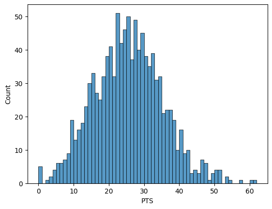

```python
import seaborn as sns
sns.histplot(data=all_games,  x=all_games['PTS'], binwidth=1)
```

Looking at the graph it appears that there are not any odd values, like numbers below zero or above one hundred. The graph's shape resembles a normal distribution.

In general the data seems to be reliable for further analysis.

### Getting more data from the API.

The following cells show the process to obtain more data from the nba_api using other endpoints and the use of pandas to prepare it.

### Retrieving Hustle stats.

Hustle stats are in the group of advanced stats because they reflect other parts of the game that are not represented in the most common stats, however their influence in the game could be decisive or make a player stand out from others in different areas of the game, making him a valuable player.

```python
from nba_api.stats.endpoints import hustlestatsboxscore #Endpoint to get the hustle stats.
hustle_stats = hustlestatsboxscore.HustleStatsBoxScore(game_id = "0042200232") #Calling for the hustle stats for a particular game.
```

```python
hustle_game_example = hustle_stats.player_stats.get_data_frame() #The result is transformed to a data frame.
print(hustle_game_example.to_string()) #The whole result is printed.
```

```
       GAME_ID     TEAM_ID TEAM_ABBREVIATION     TEAM_CITY  PLAYER_ID         PLAYER_NAME START_POSITION COMMENT MINUTES  PTS  CONTESTED_SHOTS  CONTESTED_SHOTS_2PT  CONTESTED_SHOTS_3PT  DEFLECTIONS  CHARGES_DRAWN  SCREEN_ASSISTS  SCREEN_AST_PTS  OFF_LOOSE_BALLS_RECOVERED  DEF_LOOSE_BALLS_RECOVERED  …
0   0042200232  1610612747               LAL   Los Angeles    1629020   Jarred Vanderbilt              F           19:55    6                1                    0                    1            0              0               1               2                          0                          1  …
1   0042200232  1610612747               LAL   Los Angeles       2544        LeBron James              F           28:07   23                4                    3                    1            1              0               0               0                          0                          0  …
2   0042200232  1610612747               LAL   Los Angeles     203076       Anthony Davis              C           32:55   11               14                   10                    4            2              0               4               8                          0                          0  …
3   0042200232  1610612747               LAL   Los Angeles    1630559       Austin Reaves              G           24:53    7                4                    1                    3            0              0               1               2                          0                          0  …
4   0042200232  1610612747               LAL   Los Angeles    1626156    D'Angelo Russell              G           27:45   10                5                    1                    4            2              0               1               3                          1                          0  …
5   0042200232  1610612747               LAL   Los Angeles    1629060       Rui Hachimura                          22:19   21                4                    1                    3            0              0               0               0                          0                          0  …
6   0042200232  1610612747               LAL   Los Angeles     203471     Dennis Schroder                          18:55    4                0                    0                    0            2              0               0               0                          1                          1  …
7   0042200232  1610612747               LAL   Los Angeles    1628972      Troy Brown Jr.                           8:29    0                0                    0                    0            1              0               0               0                          0                          0  …
8   0042200232  1610612747               LAL   Los Angeles    1629117      Wenyen Gabriel                           2:43    0                2                    1                    1            0              0               0               0                          0                          0  …
9   0042200232  1610612747               LAL   Los Angeles    1627736       Malik Beasley                          12:00    2                1                    1                    0            2              0               0               0                          0                          0  …
10  0042200232  1610612747               LAL   Los Angeles     202684    Tristan Thompson                          12:00    5                3                    2                    1            2              0               2               5                          0                          0  …
11  0042200232  1610612747               LAL   Los Angeles    1629022    Lonnie Walker IV                          12:00    9                1                    1                    0            2              0               0               0                          0                          0  …
12  0042200232  1610612747               LAL   Los Angeles    1631108        Max Christie                           9:15    2                1                    0                    1            0              0               0               0                          0                          0  …
13  0042200232  1610612747               LAL   Los Angeles    1627885  Shaquille Harrison                           8:44    0                2                    1                    1            4              0               0               0                          0                          1  …
14  0042200232  1610612744               GSW  Golden State     203952      Andrew Wiggins              F           29:48   11               11                    4                    7            2              0               1               2                          0                          0  …
15  0042200232  1610612744               GSW  Golden State     203210      JaMychal Green              F           12:32   15                1                    0                    1            0              0               0               0                          0                          0  …
16  0042200232  1610612744               GSW  Golden State     203110      Draymond Green              C           28:08   11               11                   10                    1            2              1               6              16                          0                          0  …
```

[output cut: 9 more lines]

```python
# The endpoint returns the hustle stats for every single player that participated in the game.
hustle_game_example.loc[hustle_game_example['PLAYER_ID'] == curry_id] # Only Curry's information is needed so his row is retrieved.
```

|  | GAME_ID | TEAM_ID | TEAM_ABBREVIATION | TEAM_CITY | PLAYER_ID | PLAYER_NAME | START_POSITION | COMMENT | MINUTES | PTS | ... | SCREEN_ASSISTS | SCREEN_AST_PTS | OFF_LOOSE_BALLS_RECOVERED | DEF_LOOSE_BALLS_RECOVERED | LOOSE_BALLS_RECOVERED | OFF_BOXOUTS | DEF_BOXOUTS | BOX_OUT_PLAYER_TEAM_REBS | BOX_OUT_PLAYER_REBS | BOX_OUTS |
| --- | --- | --- | --- | --- | --- | --- | --- | --- | --- | --- | --- | --- | --- | --- | --- | --- | --- | --- | --- | --- | --- |
| 18 | 0042200232 | 1610612744 | GSW | Golden State | 201939 | Stephen Curry | G |  | 29:32 | 20 | ... | 1 | 3 | 0 | 0 | 0 | 0 | 1 | 1 | 0 | 1 |

1 rows × 25 columns

Before writing this notebook every single endpoint here was tested to see how it works and if it would be useful. When using the `hustlestatsboxscore` a problem was found; not all games have hustle stats. However in order to practice, the endpoint was still used to show how to work with missing data and be able to create a dataset and also working around issues like this.

```python
# Two methods of forming a new dataframe using individual rows from another dataframe will be showed here.
# The first method consists on creating an empty dataframe and adding the rows (dataseries) to it.
# The second method consist on creating a list and adding the dataseries to it and finally convert the list to a dataframe.

from nba_api.stats.endpoints import hustlestatsboxscore

hustle_dataframe = pd.DataFrame() #Empty dataframe to concatenate every row containing data in the dataframe. For method number 1.
hustle_list = [] #Empty list to append every row of data. For method number 2.
no_data = [] #This list will be filled with the games ID that have no data for the hustle stats endpoint.

for game in all_games_id['GAME_ID']:

    hustle_game = hustlestatsboxscore.HustleStatsBoxScore(game_id = game)
    hustle_game = hustle_game.player_stats.get_data_frame()
    hustle_game = hustle_game.loc[hustle_game['PLAYER_ID'] == curry_id]

    #Check if the selected hustle game doesn't contain any data. If it does we concatenate to the dataframe and add it to the hustle game list or the hustle dataframe.
    if hustle_game.empty:
        no_data.append(game)
    else:
        hustle_dataframe = pd.concat([hustle_dataframe, hustle_game])
        hustle_list.append(hustle_game)

    #There is a limit for the amount of requests one can make to the API.
    #Setting a pause between every resquest avoids the limits of a request one can perform, but increases the time to complete the task.
    time.sleep(.600)


del hustle_game
 #To convert the list to a dataframe, the concatenate function is also used.
hustle_dataframe_2=pd.concat(hustle_list)

#Set an index.
hustle_dataframe = hustle_dataframe.set_index('GAME_ID',drop=False, verify_integrity=True)
hustle_dataframe_2 = hustle_dataframe_2.set_index('GAME_ID',drop=False, verify_integrity=True)
```

## Joining the hustle stats dataframe with the all the games' stats dataframe.

There are cases when two different datasets refer to the same objects but have different features and combining those datasets into one is useful to have more information in just one dataset, or table for example, and not disperse in different datasets. This exactly happens with the all_games dataframe and the hustle_dataframe dataframe; both dataframes refer to the same things, Curry’s games played, both contain different features about them, in other words the columns are different and contain different stats. Joining those two dataframes is simple and will provide all the stats from both dataframes in one as shown next.

```python
allgames_stats_complete= pd.concat([ all_games, hustle_dataframe],axis = 1, join='outer') #Joining both dataframes
```

```python
allgames_stats_complete #Displaying few rows from the created dataframe
```

| GAME_ID | SEASON_ID | Playoffs | TEAM_ID | TEAM_ABBREVIATION | TEAM_NAME | GAME_ID | GAME_DATE | MATCHUP | WL | MIN | ... | SCREEN_ASSISTS | SCREEN_AST_PTS | OFF_LOOSE_BALLS_RECOVERED | DEF_LOOSE_BALLS_RECOVERED | LOOSE_BALLS_RECOVERED | OFF_BOXOUTS | DEF_BOXOUTS | BOX_OUT_PLAYER_TEAM_REBS | BOX_OUT_PLAYER_REBS | BOX_OUTS |
| --- | --- | --- | --- | --- | --- | --- | --- | --- | --- | --- | --- | --- | --- | --- | --- | --- | --- | --- | --- | --- | --- |
| 0042200236 | 42022 | 1 | 1610612744 | GSW | Golden State Warriors | 0042200236 | 2023-05-12 | GSW @ LAL | L | 39 | ... | 0.0 | 0.0 | 0.0 | 0.0 | 0.0 | 0.0 | 0.0 | 0.0 | 0.0 | 0.0 |
| 0042200235 | 42022 | 1 | 1610612744 | GSW | Golden State Warriors | 0042200235 | 2023-05-10 | GSW vs. LAL | W | 39 | ... | 1.0 | 2.0 | 1.0 | 0.0 | 1.0 | 0.0 | 0.0 | 0.0 | 0.0 | 0.0 |
| 0042200234 | 42022 | 1 | 1610612744 | GSW | Golden State Warriors | 0042200234 | 2023-05-08 | GSW @ LAL | L | 42 | ... | 0.0 | 0.0 | 0.0 | 1.0 | 1.0 | 0.0 | 0.0 | 0.0 | 0.0 | 0.0 |
| 0042200233 | 42022 | 1 | 1610612744 | GSW | Golden State Warriors | 0042200233 | 2023-05-06 | GSW @ LAL | L | 32 | ... | 0.0 | 0.0 | 1.0 | 0.0 | 1.0 | 0.0 | 1.0 | 1.0 | 0.0 | 1.0 |
| 0042200232 | 42022 | 1 | 1610612744 | GSW | Golden State Warriors | 0042200232 | 2023-05-04 | GSW vs. LAL | W | 30 | ... | 1.0 | 3.0 | 0.0 | 0.0 | 0.0 | 0.0 | 1.0 | 1.0 | 0.0 | 1.0 |
| ... | ... | ... | ... | ... | ... | ... | ... | ... | ... | ... | ... | ... | ... | ... | ... | ... | ... | ... | ... | ... | ... |
| 0020900096 | 22009 | 0 | 1610612744 | GSW | Golden State Warriors | 0020900096 | 2009-11-08 | GSW @ SAC | L | 31 | ... | NaN | NaN | NaN | NaN | NaN | NaN | NaN | NaN | NaN | NaN |
| 0020900082 | 22009 | 0 | 1610612744 | GSW | Golden State Warriors | 0020900082 | 2009-11-06 | GSW vs. LAC | L | 22 | ... | NaN | NaN | NaN | NaN | NaN | NaN | NaN | NaN | NaN | NaN |
| 0020900069 | 22009 | 0 | 1610612744 | GSW | Golden State Warriors | 0020900069 | 2009-11-04 | GSW vs. MEM | W | 28 | ... | NaN | NaN | NaN | NaN | NaN | NaN | NaN | NaN | NaN | NaN |
| 0020900030 | 22009 | 0 | 1610612744 | GSW | Golden State Warriors | 0020900030 | 2009-10-30 | GSW @ PHX | L | 39 | ... | NaN | NaN | NaN | NaN | NaN | NaN | NaN | NaN | NaN | NaN |
| 0020900015 | 22009 | 0 | 1610612744 | GSW | Golden State Warriors | 0020900015 | 2009-10-28 | GSW vs. HOU | L | 36 | ... | 0.0 | 0.0 | 0.0 | 0.0 | 0.0 | 0.0 | 0.0 | 0.0 | 0.0 | 0.0 |

For the remainder of the notebook the code will show how to use other endpoints and retrieve more data from them but there won’t be in-depth explanations; the previous part of this notebook provides the foundation for the upcoming code. If an explanation or guide is required it will be shown as a comment in the code.

## Player career stats endpoint.

```python
#The following endpoint is used to obtain the player's career stats, during the season, playoffs and career.

from nba_api.stats.endpoints import playercareerstats

career_stats_endpoint = playercareerstats.PlayerCareerStats(player_id = curry_id)

career_totals_season = career_stats_endpoint.career_totals_regular_season.get_data_frame()
career_totals_playoffs = career_stats_endpoint.career_totals_post_season.get_data_frame()
season_rankings_playoffs = career_stats_endpoint.season_rankings_post_season.get_data_frame()
season_rankings_season = career_stats_endpoint.season_rankings_regular_season.get_data_frame()
season_totals_playoffs = career_stats_endpoint.season_totals_post_season.get_data_frame()
season_totals_season = career_stats_endpoint.season_totals_regular_season.get_data_frame()

del career_stats_endpoint
```

```python
#The dataframes are saved as CSV.
career_totals_season.to_csv('career_totals_season_csv', index=False)
career_totals_playoffs.to_csv('career_totals_playoffs_csv', index=False)
season_rankings_playoffs.to_csv('season_rankings_playoffs_csv', index=False)
season_rankings_season.to_csv('season_rankings_season_csv', index=False)
season_totals_playoffs.to_csv('season_totals_playoffs_csv', index=False)
season_totals_season.to_csv('season_totals_season_csv', index=False)
```

## Player stats in the clutch endpoint.

```python
#Season clutch stats information
from nba_api.stats.endpoints import playerdashboardbyclutch
clutchdata = []
for seasonid in years_season:

    player_clutch = playerdashboardbyclutch.PlayerDashboardByClutch(player_id = curry_id,
                                                                    season = seasonid,
                                                                    season_type_playoffs = 'Regular Season',
                                                                    league_id_nullable = LeagueID.nba)

    clutch_5min = player_clutch.last5_min5_point_player_dashboard.get_data_frame()
    if clutch_5min.empty:
        pass
    else:
        clutchdata.append(clutch_5min)

clutchdata_season = pd.concat(clutchdata)
```

```python
clutchdata_season
```

|  | GROUP_SET | GROUP_VALUE | GP | W | L | W_PCT | MIN | FGM | FGA | FG_PCT | ... | BLK_RANK | BLKA_RANK | PF_RANK | PFD_RANK | PTS_RANK | PLUS_MINUS_RANK | NBA_FANTASY_PTS_RANK | DD2_RANK | TD3_RANK | WNBA_FANTASY_PTS_RANK |
| --- | --- | --- | --- | --- | --- | --- | --- | --- | --- | --- | --- | --- | --- | --- | --- | --- | --- | --- | --- | --- | --- |
| 0 | Last 5 MIN <= 5 PTS | 2022-23 | 21 | 6 | 15 | 0.286 | 64.141667 | 23 | 47 | 0.489 | ... | 1 | 1 | 1 | 1 | 1 | 1 | 1 | 1 | 1 | 1 |
| 0 | Last 5 MIN <= 5 PTS | 2021-22 | 20 | 8 | 12 | 0.400 | 61.228333 | 16 | 47 | 0.340 | ... | 1 | 1 | 1 | 1 | 1 | 1 | 1 | 1 | 1 | 1 |
| 0 | Last 5 MIN <= 5 PTS | 2018-19 | 20 | 9 | 11 | 0.450 | 47.875000 | 18 | 37 | 0.486 | ... | 1 | 1 | 1 | 1 | 1 | 1 | 1 | 1 | 1 | 1 |
| 0 | Last 5 MIN <= 5 PTS | 2017-18 | 12 | 6 | 6 | 0.500 | 29.280000 | 7 | 16 | 0.438 | ... | 1 | 1 | 1 | 1 | 1 | 1 | 1 | 1 | 1 | 1 |
| 0 | Last 5 MIN <= 5 PTS | 2016-17 | 12 | 4 | 8 | 0.333 | 37.773333 | 12 | 30 | 0.400 | ... | 1 | 1 | 1 | 1 | 1 | 1 | 1 | 1 | 1 | 1 |
| 0 | Last 5 MIN <= 5 PTS | 2015-16 | 19 | 15 | 4 | 0.789 | 58.755000 | 22 | 50 | 0.440 | ... | 1 | 1 | 1 | 1 | 1 | 1 | 1 | 1 | 1 | 1 |
| 0 | Last 5 MIN <= 5 PTS | 2014-15 | 16 | 11 | 5 | 0.688 | 37.718333 | 13 | 31 | 0.419 | ... | 1 | 1 | 1 | 1 | 1 | 1 | 1 | 1 | 1 | 1 |
| 0 | Last 5 MIN <= 5 PTS | 2013-14 | 34 | 17 | 17 | 0.500 | 105.131667 | 34 | 83 | 0.410 | ... | 1 | 1 | 1 | 1 | 1 | 1 | 1 | 1 | 1 | 1 |
| 0 | Last 5 MIN <= 5 PTS | 2012-13 | 28 | 13 | 15 | 0.464 | 79.736667 | 16 | 39 | 0.410 | ... | 1 | 1 | 1 | 1 | 1 | 1 | 1 | 1 | 1 | 1 |
| 0 | Last 5 MIN <= 5 PTS | 2023-24 | 22 | 6 | 16 | 0.273 | 69.078333 | 34 | 60 | 0.567 | ... | 1 | 1 | 1 | 1 | 1 | 1 | 1 | 1 | 1 | 1 |
| 0 | Last 5 MIN <= 5 PTS | 2020-21 | 24 | 11 | 13 | 0.458 | 56.616667 | 21 | 46 | 0.457 | ... | 1 | 1 | 1 | 1 | 1 | 1 | 1 | 1 | 1 | 1 |
| 0 | Last 5 MIN <= 5 PTS | 2019-20 | 1 | 0 | 1 | 0.000 | 1.745000 | 0 | 1 | 0.000 | ... | 1 | 1 | 1 | 1 | 1 | 1 | 1 | 1 | 1 | 1 |
| 0 | Last 5 MIN <= 5 PTS | 2011-12 | 9 | 2 | 7 | 0.222 | 18.735000 | 3 | 12 | 0.250 | ... | 1 | 1 | 1 | 1 | 1 | 1 | 1 | 1 | 1 | 1 |
| 0 | Last 5 MIN <= 5 PTS | 2010-11 | 27 | 7 | 20 | 0.259 | 73.495000 | 15 | 34 | 0.441 | ... | 1 | 1 | 1 | 1 | 1 | 1 | 1 | 1 | 1 | 1 |
| 0 | Last 5 MIN <= 5 PTS | 2009-10 | 31 | 6 | 25 | 0.194 | 85.781667 | 14 | 37 | 0.378 | ... | 1 | 1 | 1 | 1 | 1 | 1 | 1 | 1 | 1 | 1 |

15 rows × 62 columns

```python
clutchdata_season.to_csv('clutchdata_season_csv', index=False)
```

```python
#playoffs clutch stats information
from nba_api.stats.endpoints import playerdashboardbyclutch
clutchdata = []
for seasonid in years_season:

    player_clutch = playerdashboardbyclutch.PlayerDashboardByClutch(player_id = curry_id,
                                                                    season = seasonid,
                                                                    season_type_playoffs = 'Playoffs',
                                                                    league_id_nullable = LeagueID.nba)

    clutch_5min = player_clutch.last5_min5_point_player_dashboard.get_data_frame()
    if clutch_5min.empty:
        pass
    else:
        clutchdata.append(clutch_5min)

del player_clutch
clutchdata_playoffs = pd.concat(clutchdata)
```

```python
clutchdata_playoffs.to_csv('clutchdata_playoffs_csv', index=False)
print(clutchdata_playoffs.to_string()) #Clutch data in the playoffs
```

```
             GROUP_SET GROUP_VALUE  GP  W  L  W_PCT        MIN  FGM  FGA  FG_PCT  FG3M  FG3A  FG3_PCT  FTM  FTA  FT_PCT  OREB  DREB  REB  AST  TOV  STL  BLK  BLKA  PF  PFD  PTS  PLUS_MINUS  NBA_FANTASY_PTS  DD2  TD3  WNBA_FANTASY_PTS  GP_RANK  W_RANK  L_RANK  W_PCT_RANK  MIN_RANK  FGM_RANK  FGA_RANK…
0  Last 5 MIN <= 5 PTS     2022-23   4  0  4  0.000  13.316667    6   14   0.429     3     8    0.375    1    1     1.0     0     2    2    1    1    0    0     1   2    1   16          -6             18.9    1    1              22.0        1       1       1           1         1         1         1…
0  Last 5 MIN <= 5 PTS     2021-22   8  5  3  0.625  15.545000    5   13   0.385     1     6    0.167    6    6     1.0     1     2    3    4    0    0    0     2   1    4   17          13             26.6    1    0              25.0        1       1       1           1         1         1         1…
0  Last 5 MIN <= 5 PTS     2018-19   9  4  5  0.444  31.621667    4   21   0.190     3    13    0.231    4    4     1.0     1     2    3    2    3    0    0     3   2    4   15          15             18.6    1    1              23.0        1       1       1           1         1         1         1…
0  Last 5 MIN <= 5 PTS     2017-18   4  2  2  0.500  10.883333    3    7   0.429     0     1    0.000    2    2     1.0     0     2    2    0    1    0    0     0   0    2    8           2              9.4    0    0              10.0        1       1       1           1         1         1         1…
0  Last 5 MIN <= 5 PTS     2016-17   2  2  0  1.000   5.761667    1    2   0.500     1     2    0.500    0    0     0.0     1     1    2    0    0    0    0     0   1    0    3           8              5.4    1    0               6.0        1       1       1           1         1         1         1…
0  Last 5 MIN <= 5 PTS     2015-16   4  2  2  0.500  17.900000    8   16   0.500     5    11    0.455    0    0     0.0     1     2    3    2    1    0    0     1   3    0   21          14             26.6    2    0              31.0        1       1       1           1         1         1         1…
0  Last 5 MIN <= 5 PTS     2014-15   5  2  3  0.400  20.396667    7   16   0.438     4    10    0.400    3    3     1.0     0     5    5    0    6    0    0     2   3    2   21           2             21.0    0    0              30.0        1       1       1           1         1         1         1…
0  Last 5 MIN <= 5 PTS     2013-14   3  1  2  0.333   8.831667    1    7   0.143     1     3    0.333    6    6     1.0     0     1    1    1    1    0    0     2   2    3    9          -4             10.7    1    0              12.0        1       1       1           1         1         1         1…
0  Last 5 MIN <= 5 PTS     2012-13   6  1  5  0.167  20.353333    4   15   0.267     1     6    0.167    2    2     1.0     0     0    0    2    1    1    0     2   1    2   11           0             16.0    1    0              16.0        1       1       1           1         1         1         1…
```

## Player pass endpoint.

```python
#Since a player can receive or throw a pass two datasets will be created for each one of these cases.
season_pass_received = []
season_pass_made = []
```

```python
#This code is for every season.
from nba_api.stats.endpoints import playerdashptpass

for seasonid in years_season:

    player = playerdashptpass.PlayerDashPtPass(player_id = curry_id,
                                                  team_id = warriors_id,
                                                  season = seasonid,
                                                  season_type_all_star = 'Regular Season',
                                                  league_id = LeagueID.nba)
    pass_made = player.passes_made.get_data_frame()
    pass_received = player.passes_received.get_data_frame()
    pass_made.insert(loc=0, column="Year", value=seasonid) #Insert a column with the year of the season.
    pass_made.insert(loc=1, column="Playoffs", value=0) #Insert a column to inform if it was during the playoffs
    pass_received.insert(loc=0, column="Year", value=seasonid)
    pass_received.insert(loc=1, column="Playoffs", value=0)
    season_pass_received.append(pass_received)
    season_pass_made.append(pass_made)

    del player
```

```python
season_pass_received=pd.concat(season_pass_received)
season_pass_received.to_csv('season_pass_received_csv', index=False)
print(season_pass_received.to_string()) #Display the stats for the passes Curry received.
```

[output not shown]

```python
season_pass_made=pd.concat(season_pass_made)
season_pass_made.to_csv('season_pass_made_csv', index=False)
print(season_pass_made.to_string()) #Display the stats related to the passes Curry made.
```

[output not shown]

```python
#Create the passing datasets for the playoffs.
playoffs_pass_received = []
playoffs_pass_made = []
```

```python
from nba_api.stats.endpoints import playerdashptpass

for seasonid in years_season:

    player = playerdashptpass.PlayerDashPtPass(player_id = curry_id,
                                                  team_id = warriors_id,
                                                  season = seasonid,
                                                  season_type_all_star = 'Playoffs',
                                                  league_id = LeagueID.nba)
    pass_made = player.passes_made.get_data_frame()
    pass_received = player.passes_received.get_data_frame()
    pass_made.insert(loc=0, column="Year", value=seasonid)
    pass_made.insert(loc=1, column="Playoffs", value=1)
    pass_received.insert(loc=0, column="Year", value=seasonid)
    pass_received.insert(loc=1, column="Playoffs", value=1)
    playoffs_pass_received.append(pass_received)
    playoffs_pass_made.append(pass_made)

del player
```

```python
playoffs_pass_made=pd.concat(playoffs_pass_made)
playoffs_pass_made.to_csv('playoffs_pass_made_csv', index=False)
```

```python
playoffs_pass_received=pd.concat(playoffs_pass_received)
playoffs_pass_received.to_csv('playoffs_pass_received_csv', index=False)
```

## Player rebounds endpoint.

```python
#playoffs code
from nba_api.stats.endpoints import playerdashptreb

playoffs_rebounds = []

for seasonid in years_season:

    player = playerdashptreb.PlayerDashPtReb(player_id = curry_id,
                                                  team_id = warriors_id,
                                                  season = seasonid,
                                                  season_type_all_star = 'Playoffs',
                                                  league_id = LeagueID.nba)
    rebounds = player.overall_rebounding.get_data_frame()
    rebounds.insert(loc=0, column="Year", value=seasonid)
    rebounds.insert(loc=1, column="Playoffs", value=1)
    playoffs_rebounds.append(rebounds)
    time.sleep(.600)

    del player
```

```python
playoffs_rebounds=pd.concat(playoffs_rebounds)
playoffs_rebounds.to_csv('playoffs_rebounds_csv', index=False)
print(playoffs_rebounds.to_string())
```

```
      Year  Playoffs PLAYER_ID PLAYER_NAME_LAST_FIRST   G  OVERALL  REB_FREQUENCY OREB DREB  REB C_OREB C_DREB C_REB  C_REB_PCT UC_OREB UC_DREB UC_REB  UC_REB_PCT
0  2022-23         1    201939         Curry, Stephen  13  Overall          1.000    9   58   67      5     14    19      0.284       4      44     48       0.716
0  2021-22         1    201939         Curry, Stephen  22  Overall          0.991   11  103  114      3     11    14      0.123       8      92    100       0.877
0  2018-19         1    201939         Curry, Stephen  22  Overall          0.992   17  114  131      9     20    29      0.221       8      94    102       0.779
0  2017-18         1    201939         Curry, Stephen  15  Overall          0.989    8   82   90      3     12    15      0.167       5      70     75       0.833
0  2016-17         1    201939         Curry, Stephen  17  Overall          1.009   21   86  107     13     11    24      0.224       8      75     83       0.776
0  2015-16         1    201939         Curry, Stephen  18  Overall          1.000   14   85   99      8     16    24      0.242       6      69     75       0.758
0  2014-15         1    201939         Curry, Stephen  21  Overall          0.990   19   85  104      7     18    25      0.240      12      67     79       0.760
0  2013-14         1    201939         Curry, Stephen   7  Overall          1.000    4   21   25      2      5     7      0.280       2      16     18       0.720
```

```python
#season code
from nba_api.stats.endpoints import playerdashptreb

season_rebounds = []

for seasonid in years_season:

    player = playerdashptreb.PlayerDashPtReb(player_id = curry_id,
                                                  team_id = warriors_id,
                                                  season = seasonid,
                                                  season_type_all_star = 'Regular Season',
                                                  league_id = LeagueID.nba)
    rebounds = player.overall_rebounding.get_data_frame()
    rebounds.insert(loc=0, column="Year", value=seasonid)
    rebounds.insert(loc=1, column="Playoffs", value=0)
    season_rebounds.append(rebounds)
    time.sleep(.600)

del player
```

```python
season_rebounds=pd.concat(season_rebounds)
season_rebounds.to_csv('season_rebounds_csv', index=False)
print(season_rebounds.to_string())
```

```
      Year  Playoffs PLAYER_ID PLAYER_NAME_LAST_FIRST   G  OVERALL  REB_FREQUENCY OREB DREB  REB C_OREB C_DREB C_REB  C_REB_PCT UC_OREB UC_DREB UC_REB  UC_REB_PCT
0  2022-23         0    201939         Curry, Stephen  56  Overall          0.988   39  298  337     17     55    72      0.214      22     243    265       0.786
0  2021-22         0    201939         Curry, Stephen  64  Overall          1.000   34  301  335     16     43    59      0.176      18     258    276       0.824
0  2018-19         0    201939         Curry, Stephen  69  Overall          0.984   44  319  363     18     57    75      0.207      26     262    288       0.793
0  2017-18         0    201939         Curry, Stephen  51  Overall          1.000   36  225  261     11     38    49      0.188      25     187    212       0.812
0  2016-17         0    201939         Curry, Stephen  79  Overall          1.003   60  294  354     36     38    74      0.209      24     256    280       0.791
0  2015-16         0    201939         Curry, Stephen  79  Overall          1.007   68  365  433     26     56    82      0.189      42     309    351       0.811
0  2014-15         0    201939         Curry, Stephen  80  Overall          0.991   56  282  338     22     54    76      0.225      34     228    262       0.775
0  2013-14         0    201939         Curry, Stephen  78  Overall          1.012   48  290  338     14     52    66      0.195      34     238    272       0.805
0  2023-24         0    201939         Curry, Stephen  63  Overall          0.986   34  243  277     12     32    44      0.159      22     211    233       0.841
0  2020-21         0    201939         Curry, Stephen  63  Overall          0.997   28  316  344     16     51    67      0.195      12     265    277       0.805
0  2019-20         0    201939         Curry, Stephen   5  Overall          1.000    4   22   26      3      5     8      0.308       1      17     18       0.692
```

## Player shots endpoint.

```python
#season code
from nba_api.stats.endpoints import playerdashptshots

#different methods to obtain specific stats from the used endpoint
closest_defender_slist = []
closest_defender10ft_slist = []
general_shooting_slist = []
overall_slist = []
shot_clock_slist = []
touch_time_slist = []
dribble_shooting_slist = []

for seasonid in years_season:

    player = playerdashptshots.PlayerDashPtShots(player_id = curry_id,
                                                  team_id = warriors_id,
                                                  season = seasonid,
                                                  season_type_all_star = 'Regular Season',
                                                  league_id = LeagueID.nba)
    #closest_defender_shooting
    closest_defender_unit = player.closest_defender_shooting.get_data_frame()
    closest_defender_unit.insert(loc=0, column="Year", value=seasonid)
    closest_defender_unit.insert(loc=1, column="Playoffs", value=0)
    closest_defender_slist.append(closest_defender_unit)
    time.sleep(.600)

    #closest_defender10ft_plus_shooting

    closest_defender10ft_unit = player.closest_defender10ft_plus_shooting.get_data_frame()
    closest_defender10ft_unit.insert(loc=0, column="Year", value=seasonid)
    closest_defender10ft_unit.insert(loc=1, column="Playoffs", value=0)
    closest_defender10ft_slist.append(closest_defender10ft_unit)
    time.sleep(.600)

    #general_shooting

    general_shooting_unit = player.general_shooting.get_data_frame()
    general_shooting_unit.insert(loc=0, column="Year", value=seasonid)
    general_shooting_unit.insert(loc=1, column="Playoffs", value=0)
    general_shooting_slist.append(general_shooting_unit)
    time.sleep(.600)


    #overall
    overall_unit = player.overall.get_data_frame()
    overall_unit.insert(loc=0, column="Year", value=seasonid)
    overall_unit.insert(loc=1, column="Playoffs", value=0)
    overall_slist.append(overall_unit)
    time.sleep(.600)


    #shot_clock_shooting

    shot_clock_unit = player.shot_clock_shooting.get_data_frame()
    shot_clock_unit.insert(loc=0, column="Year", value=seasonid)
    shot_clock_unit.insert(loc=1, column="Playoffs", value=0)
    shot_clock_slist.append(shot_clock_unit)
    time.sleep(.600)

    #touch_time_shooting

    touch_time_unit = player.touch_time_shooting.get_data_frame()
    touch_time_unit.insert(loc=0, column="Year", value=seasonid)
    touch_time_unit.insert(loc=1, column="Playoffs", value=0)
    touch_time_slist.append(touch_time_unit)
    time.sleep(.600)

    #dribble_shooting

    dribble_shooting_unit = player.dribble_shooting.get_data_frame()
    dribble_shooting_unit.insert(loc=0, column="Year", value=seasonid)
    dribble_shooting_unit.insert(loc=1, column="Playoffs", value=0)
    dribble_shooting_slist.append(dribble_shooting_unit)
    time.sleep(.600)
    del player

closest_defender_slist = pd.concat(closest_defender_slist)
closest_defender10ft_slist = pd.concat(closest_defender10ft_slist)
general_shooting_slist = pd.concat(general_shooting_slist)
overall_slist = pd.concat(overall_slist)
shot_clock_slist = pd.concat(shot_clock_slist)
touch_time_slist = pd.concat(touch_time_slist)
dribble_shooting_slist = pd.concat(dribble_shooting_slist)

closest_defender_slist.to_csv('closest_defender_slist_csv', index=False)
closest_defender10ft_slist.to_csv('closest_defender10ft_slist_csv', index=False)
general_shooting_slist.to_csv('general_shooting_slist_csv', index=False)
overall_slist.to_csv('overall_slistt_csv', index=False)
shot_clock_slist.to_csv('shot_clock_slist_csv', index=False)
touch_time_slist.to_csv('touch_time_slist_csv', index=False)
dribble_shooting_slist.to_csv('dribble_shooting_slist_csv', index=False)
```

```python
closest_defender_slist
```

|  | Year | Playoffs | PLAYER_ID | PLAYER_NAME_LAST_FIRST | SORT_ORDER | GP | G | CLOSE_DEF_DIST_RANGE | FGA_FREQUENCY | FGM | ... | FG_PCT | EFG_PCT | FG2A_FREQUENCY | FG2M | FG2A | FG2_PCT | FG3A_FREQUENCY | FG3M | FG3A | FG3_PCT |
| --- | --- | --- | --- | --- | --- | --- | --- | --- | --- | --- | --- | --- | --- | --- | --- | --- | --- | --- | --- | --- | --- |
| 0 | 2022-23 | 0 | 201939 | Curry, Stephen | 1 | 55 | 43 | 0-2 Feet - Very Tight | 0.073 | 39 | ... | 0.476 | 0.518 | 0.063 | 32 | 71 | 0.451 | 0.010 | 7 | 11 | 0.636 |
| 1 | 2022-23 | 0 | 201939 | Curry, Stephen | 2 | 55 | 55 | 2-4 Feet - Tight | 0.337 | 193 | ... | 0.511 | 0.558 | 0.231 | 157 | 259 | 0.606 | 0.106 | 36 | 119 | 0.303 |
| 2 | 2022-23 | 0 | 201939 | Curry, Stephen | 3 | 55 | 55 | 4-6 Feet - Open | 0.407 | 218 | ... | 0.478 | 0.636 | 0.117 | 74 | 131 | 0.565 | 0.290 | 144 | 325 | 0.443 |
| 3 | 2022-23 | 0 | 201939 | Curry, Stephen | 4 | 55 | 52 | 6+ Feet - Wide Open | 0.183 | 103 | ... | 0.502 | 0.707 | 0.025 | 19 | 28 | 0.679 | 0.158 | 84 | 177 | 0.475 |
| 0 | 2021-22 | 0 | 201939 | Curry, Stephen | 1 | 64 | 42 | 0-2 Feet - Very Tight | 0.053 | 21 | ... | 0.323 | 0.377 | 0.041 | 14 | 50 | 0.280 | 0.012 | 7 | 15 | 0.467 |
| 1 | 2021-22 | 0 | 201939 | Curry, Stephen | 2 | 64 | 64 | 2-4 Feet - Tight | 0.372 | 223 | ... | 0.490 | 0.565 | 0.236 | 155 | 289 | 0.536 | 0.136 | 68 | 166 | 0.410 |
| 2 | 2021-22 | 0 | 201939 | Curry, Stephen | 3 | 64 | 64 | 4-6 Feet - Open | 0.395 | 198 | ... | 0.410 | 0.543 | 0.093 | 69 | 114 | 0.605 | 0.302 | 129 | 369 | 0.350 |
| 3 | 2021-22 | 0 | 201939 | Curry, Stephen | 4 | 64 | 59 | 6+ Feet - Wide Open | 0.180 | 93 | ... | 0.423 | 0.607 | 0.018 | 12 | 22 | 0.545 | 0.162 | 81 | 198 | 0.409 |
| 0 | 2018-19 | 0 | 201939 | Curry, Stephen | 1 | 69 | 46 | 0-2 Feet - Very Tight | 0.074 | 43 | ... | 0.439 | 0.464 | 0.064 | 38 | 84 | 0.452 | 0.011 | 5 | 14 | 0.357 |
| 1 | 2018-19 | 0 | 201939 | Curry, Stephen | 2 | 69 | 68 | 2-4 Feet - Tight | 0.311 | 198 | ... | 0.483 | 0.550 | 0.199 | 143 | 262 | 0.546 | 0.112 | 55 | 148 | 0.372 |
| 2 | 2018-19 | 0 | 201939 | Curry, Stephen | 3 | 69 | 69 | 4-6 Feet - Open | 0.367 | 208 | ... | 0.430 | 0.574 | 0.094 | 68 | 124 | 0.548 | 0.273 | 140 | 360 | 0.389 |
| 3 | 2018-19 | 0 | 201939 | Curry, Stephen | 4 | 69 | 68 | 6+ Feet - Wide Open | 0.248 | 172 | ... | 0.526 | 0.749 | 0.036 | 26 | 48 | 0.542 | 0.212 | 146 | 279 | 0.523 |
| 0 | 2017-18 | 0 | 201939 | Curry, Stephen | 1 | 51 | 42 | 0-2 Feet - Very Tight | 0.110 | 53 | ... | 0.570 | 0.597 | 0.096 | 48 | 81 | 0.593 | 0.014 | 5 | 12 | 0.417 |
| 1 | 2017-18 | 0 | 201939 | Curry, Stephen | 2 | 51 | 50 | 2-4 Feet - Tight | 0.292 | 125 | ... | 0.508 | 0.565 | 0.185 | 97 | 156 | 0.622 | 0.107 | 28 | 90 | 0.311 |
| 2 | 2017-18 | 0 | 201939 | Curry, Stephen | 3 | 51 | 51 | 4-6 Feet - Open | 0.307 | 125 | ... | 0.483 | 0.639 | 0.084 | 44 | 71 | 0.620 | 0.223 | 81 | 188 | 0.431 |
| 3 | 2017-18 | 0 | 201939 | Curry, Stephen | 4 | 51 | 50 | 6+ Feet - Wide Open | 0.291 | 125 | ... | 0.510 | 0.710 | 0.044 | 27 | 37 | 0.730 | 0.247 | 98 | 208 | 0.471 |
| 0 | 2016-17 | 0 | 201939 | Curry, Stephen | 1 | 79 | 65 | 0-2 Feet - Very Tight | 0.107 | 77 | ... | 0.520 | 0.547 | 0.089 | 69 | 124 | 0.556 | 0.017 | 8 | 24 | 0.333 |
| 1 | 2016-17 | 0 | 201939 | Curry, Stephen | 2 | 79 | 77 | 2-4 Feet - Tight | 0.274 | 191 | ... | 0.501 | 0.555 | 0.179 | 150 | 249 | 0.602 | 0.095 | 41 | 132 | 0.311 |
| 2 | 2016-17 | 0 | 201939 | Curry, Stephen | 3 | 79 | 79 | 4-6 Feet - Open | 0.357 | 231 | ... | 0.467 | 0.602 | 0.125 | 97 | 173 | 0.561 | 0.232 | 134 | 322 | 0.416 |
| 3 | 2016-17 | 0 | 201939 | Curry, Stephen | 4 | 79 | 78 | 6+ Feet - Wide Open | 0.262 | 176 | ... | 0.484 | 0.677 | 0.043 | 35 | 60 | 0.583 | 0.219 | 141 | 304 | 0.464 |
| 0 | 2015-16 | 0 | 201939 | Curry, Stephen | 1 | 79 | 69 | 0-2 Feet - Very Tight | 0.113 | 90 | ... | 0.514 | 0.529 | 0.098 | 85 | 152 | 0.559 | 0.015 | 5 | 23 | 0.217 |
| 1 | 2015-16 | 0 | 201939 | Curry, Stephen | 2 | 79 | 78 | 2-4 Feet - Tight | 0.297 | 245 | ... | 0.534 | 0.607 | 0.190 | 178 | 293 | 0.608 | 0.107 | 67 | 166 | 0.404 |
| 2 | 2015-16 | 0 | 201939 | Curry, Stephen | 3 | 79 | 79 | 4-6 Feet - Open | 0.378 | 306 | ... | 0.524 | 0.692 | 0.110 | 110 | 170 | 0.647 | 0.268 | 196 | 414 | 0.473 |
| 3 | 2015-16 | 0 | 201939 | Curry, Stephen | 4 | 79 | 77 | 6+ Feet - Wide Open | 0.212 | 164 | ... | 0.500 | 0.704 | 0.032 | 30 | 49 | 0.612 | 0.180 | 134 | 279 | 0.480 |
| 0 | 2014-15 | 0 | 201939 | Curry, Stephen | 1 | 80 | 59 | 0-2 Feet - Very Tight | 0.102 | 66 | ... | 0.496 | 0.504 | 0.094 | 64 | 123 | 0.520 | 0.008 | 2 | 10 | 0.200 |
| 1 | 2014-15 | 0 | 201939 | Curry, Stephen | 2 | 80 | 80 | 2-4 Feet - Tight | 0.329 | 223 | ... | 0.520 | 0.587 | 0.221 | 165 | 288 | 0.573 | 0.108 | 58 | 141 | 0.411 |
| 2 | 2014-15 | 0 | 201939 | Curry, Stephen | 3 | 80 | 78 | 4-6 Feet - Open | 0.317 | 201 | ... | 0.486 | 0.612 | 0.143 | 96 | 186 | 0.516 | 0.175 | 105 | 228 | 0.461 |
| 3 | 2014-15 | 0 | 201939 | Curry, Stephen | 4 | 80 | 78 | 6+ Feet - Wide Open | 0.252 | 163 | ... | 0.495 | 0.679 | 0.052 | 42 | 68 | 0.618 | 0.200 | 121 | 261 | 0.464 |
| 0 | 2013-14 | 0 | 201939 | Curry, Stephen | 1 | 77 | 52 | 0-2 Feet - Very Tight | 0.083 | 59 | ... | 0.536 | 0.568 | 0.068 | 52 | 90 | 0.578 | 0.015 | 7 | 20 | 0.350 |
| 1 | 2013-14 | 0 | 201939 | Curry, Stephen | 2 | 77 | 77 | 2-4 Feet - Tight | 0.312 | 191 | ... | 0.464 | 0.516 | 0.225 | 148 | 297 | 0.498 | 0.087 | 43 | 115 | 0.374 |
| 2 | 2013-14 | 0 | 201939 | Curry, Stephen | 3 | 77 | 77 | 4-6 Feet - Open | 0.386 | 249 | ... | 0.489 | 0.592 | 0.195 | 144 | 257 | 0.560 | 0.191 | 105 | 252 | 0.417 |
| 3 | 2013-14 | 0 | 201939 | Curry, Stephen | 4 | 77 | 73 | 6+ Feet - Wide Open | 0.218 | 136 | ... | 0.472 | 0.644 | 0.056 | 37 | 74 | 0.500 | 0.162 | 99 | 214 | 0.463 |
| 0 | 2023-24 | 0 | 201939 | Curry, Stephen | 1 | 63 | 38 | 0-2 Feet - Very Tight | 0.061 | 36 | ... | 0.486 | 0.514 | 0.054 | 32 | 65 | 0.492 | 0.007 | 4 | 9 | 0.444 |
| 1 | 2023-24 | 0 | 201939 | Curry, Stephen | 2 | 63 | 62 | 2-4 Feet - Tight | 0.310 | 173 | ... | 0.461 | 0.520 | 0.207 | 129 | 251 | 0.514 | 0.102 | 44 | 124 | 0.355 |
| 2 | 2023-24 | 0 | 201939 | Curry, Stephen | 3 | 63 | 63 | 4-6 Feet - Open | 0.427 | 216 | ... | 0.418 | 0.568 | 0.100 | 61 | 121 | 0.504 | 0.327 | 155 | 396 | 0.391 |
| 3 | 2023-24 | 0 | 201939 | Curry, Stephen | 4 | 63 | 62 | 6+ Feet - Wide Open | 0.201 | 117 | ... | 0.481 | 0.681 | 0.025 | 20 | 30 | 0.667 | 0.176 | 97 | 213 | 0.455 |
| 0 | 2020-21 | 0 | 201939 | Curry, Stephen | 1 | 63 | 49 | 0-2 Feet - Very Tight | 0.073 | 54 | ... | 0.545 | 0.606 | 0.053 | 42 | 72 | 0.583 | 0.020 | 12 | 27 | 0.444 |
| 1 | 2020-21 | 0 | 201939 | Curry, Stephen | 2 | 63 | 62 | 2-4 Feet - Tight | 0.427 | 280 | ... | 0.483 | 0.554 | 0.262 | 197 | 355 | 0.555 | 0.166 | 83 | 225 | 0.369 |
| 2 | 2020-21 | 0 | 201939 | Curry, Stephen | 3 | 63 | 63 | 4-6 Feet - Open | 0.364 | 231 | ... | 0.468 | 0.634 | 0.084 | 67 | 114 | 0.588 | 0.280 | 164 | 380 | 0.432 |
| 3 | 2020-21 | 0 | 201939 | Curry, Stephen | 4 | 63 | 58 | 6+ Feet - Wide Open | 0.136 | 90 | ... | 0.489 | 0.696 | 0.016 | 14 | 22 | 0.636 | 0.119 | 76 | 162 | 0.469 |
| 0 | 2019-20 | 0 | 201939 | Curry, Stephen | 1 | 5 | 3 | 0-2 Feet - Very Tight | 0.061 | 2 | ... | 0.400 | 0.400 | 0.049 | 2 | 4 | 0.500 | 0.012 | 0 | 1 | 0.000 |
| 1 | 2019-20 | 0 | 201939 | Curry, Stephen | 2 | 5 | 5 | 2-4 Feet - Tight | 0.476 | 16 | ... | 0.410 | 0.436 | 0.256 | 14 | 21 | 0.667 | 0.220 | 2 | 18 | 0.111 |
| 2 | 2019-20 | 0 | 201939 | Curry, Stephen | 3 | 5 | 5 | 4-6 Feet - Open | 0.354 | 11 | ... | 0.379 | 0.500 | 0.085 | 4 | 7 | 0.571 | 0.268 | 7 | 22 | 0.318 |
| 3 | 2019-20 | 0 | 201939 | Curry, Stephen | 4 | 5 | 5 | 6+ Feet - Wide Open | 0.110 | 4 | ... | 0.444 | 0.611 | 0.012 | 1 | 1 | 1.000 | 0.098 | 3 | 8 | 0.375 |

44 rows × 21 columns

```python
#playoffs code
from nba_api.stats.endpoints import playerdashptshots

closest_defender_plist = []
closest_defender10ft_plist = []
general_shooting_plist = []
overall_plist = []
shot_clock_plist = []
touch_time_plist = []
dribble_shooting_plist = []

for seasonid in years_season:

    player = playerdashptshots.PlayerDashPtShots(player_id = curry_id,
                                                  team_id = warriors_id,
                                                  season = seasonid,
                                                  season_type_all_star = 'Playoffs',
                                                  league_id = LeagueID.nba)
    #closest_defender_shooting
    closest_defender_unit = player.closest_defender_shooting.get_data_frame()
    closest_defender_unit.insert(loc=0, column="Year", value=seasonid)
    closest_defender_unit.insert(loc=1, column="Playoffs", value=1)
    closest_defender_plist.append(closest_defender_unit)


    #closest_defender10ft_plus_shooting

    closest_defender10ft_unit = player.closest_defender10ft_plus_shooting.get_data_frame()
    closest_defender10ft_unit.insert(loc=0, column="Year", value=seasonid)
    closest_defender10ft_unit.insert(loc=1, column="Playoffs", value=1)
    closest_defender10ft_plist.append(closest_defender10ft_unit)


    #general_shooting

    general_shooting_unit = player.general_shooting.get_data_frame()
    general_shooting_unit.insert(loc=0, column="Year", value=seasonid)
    general_shooting_unit.insert(loc=1, column="Playoffs", value=1)
    general_shooting_plist.append(general_shooting_unit)



    #overall
    overall_unit = player.overall.get_data_frame()
    overall_unit.insert(loc=0, column="Year", value=seasonid)
    overall_unit.insert(loc=1, column="Playoffs", value=1)
    overall_plist.append(overall_unit)



    #shot_clock_shooting

    shot_clock_unit = player.shot_clock_shooting.get_data_frame()
    shot_clock_unit.insert(loc=0, column="Year", value=seasonid)
    shot_clock_unit.insert(loc=1, column="Playoffs", value=1)
    shot_clock_plist.append(shot_clock_unit)


    #touch_time_shooting

    touch_time_unit = player.touch_time_shooting.get_data_frame()
    touch_time_unit.insert(loc=0, column="Year", value=seasonid)
    touch_time_unit.insert(loc=1, column="Playoffs", value=1)
    touch_time_plist.append(touch_time_unit)


    #dribble_shooting

    dribble_shooting_unit = player.dribble_shooting.get_data_frame()
    dribble_shooting_unit.insert(loc=0, column="Year", value=seasonid)
    dribble_shooting_unit.insert(loc=1, column="Playoffs", value=1)
    dribble_shooting_plist.append(dribble_shooting_unit)


    del player

closest_defender_plist = pd.concat(closest_defender_plist)
closest_defender10ft_plist = pd.concat(closest_defender10ft_plist)
general_shooting_plist = pd.concat(general_shooting_plist)
overall_plist = pd.concat(overall_plist)
shot_clock_plist = pd.concat(shot_clock_plist)
touch_time_plist = pd.concat(touch_time_plist)
dribble_shooting_plist = pd.concat(dribble_shooting_plist)

closest_defender_plist.to_csv('closest_defender_plist_csv', index=False)
closest_defender10ft_plist.to_csv('closest_defender10ft_plist_csv', index=False)
general_shooting_plist.to_csv('general_shooting_plist_csv', index=False)
overall_plist.to_csv('overall_plist_csv', index=False)
shot_clock_plist.to_csv('shot_clock_plist_csv', index=False)
touch_time_plist.to_csv('touch_time_plist_csv', index=False)
dribble_shooting_plist.to_csv('dribble_shooting_plist_csv', index=False)
```

```python
closest_defender_plist
```

|  | Year | Playoffs | PLAYER_ID | PLAYER_NAME_LAST_FIRST | SORT_ORDER | GP | G | CLOSE_DEF_DIST_RANGE | FGA_FREQUENCY | FGM | ... | FG_PCT | EFG_PCT | FG2A_FREQUENCY | FG2M | FG2A | FG2_PCT | FG3A_FREQUENCY | FG3M | FG3A | FG3_PCT |
| --- | --- | --- | --- | --- | --- | --- | --- | --- | --- | --- | --- | --- | --- | --- | --- | --- | --- | --- | --- | --- | --- |
| 0 | 2022-23 | 1 | 201939 | Curry, Stephen | 1 | 13 | 10 | 0-2 Feet - Very Tight | 0.084 | 9 | ... | 0.346 | 0.346 | 0.068 | 9 | 21 | 0.429 | 0.016 | 0 | 5 | 0.000 |
| 1 | 2022-23 | 1 | 201939 | Curry, Stephen | 2 | 13 | 13 | 2-4 Feet - Tight | 0.450 | 68 | ... | 0.486 | 0.543 | 0.302 | 52 | 94 | 0.553 | 0.148 | 16 | 46 | 0.348 |
| 2 | 2022-23 | 1 | 201939 | Curry, Stephen | 3 | 13 | 13 | 4-6 Feet - Open | 0.386 | 61 | ... | 0.508 | 0.654 | 0.119 | 26 | 37 | 0.703 | 0.267 | 35 | 83 | 0.422 |
| 3 | 2022-23 | 1 | 201939 | Curry, Stephen | 4 | 13 | 10 | 6+ Feet - Wide Open | 0.080 | 7 | ... | 0.280 | 0.400 | 0.006 | 1 | 2 | 0.500 | 0.074 | 6 | 23 | 0.261 |
| 0 | 2021-22 | 1 | 201939 | Curry, Stephen | 1 | 22 | 17 | 0-2 Feet - Very Tight | 0.070 | 13 | ... | 0.419 | 0.435 | 0.057 | 12 | 25 | 0.480 | 0.014 | 1 | 6 | 0.167 |
| 1 | 2021-22 | 1 | 201939 | Curry, Stephen | 2 | 22 | 22 | 2-4 Feet - Tight | 0.414 | 91 | ... | 0.500 | 0.563 | 0.282 | 68 | 124 | 0.548 | 0.132 | 23 | 58 | 0.397 |
| 2 | 2021-22 | 1 | 201939 | Curry, Stephen | 3 | 22 | 22 | 4-6 Feet - Open | 0.348 | 69 | ... | 0.451 | 0.601 | 0.102 | 23 | 45 | 0.511 | 0.245 | 46 | 108 | 0.426 |
| 3 | 2021-22 | 1 | 201939 | Curry, Stephen | 4 | 22 | 21 | 6+ Feet - Wide Open | 0.168 | 29 | ... | 0.392 | 0.534 | 0.039 | 8 | 17 | 0.471 | 0.130 | 21 | 57 | 0.368 |
| 0 | 2018-19 | 1 | 201939 | Curry, Stephen | 1 | 22 | 21 | 0-2 Feet - Very Tight | 0.123 | 21 | ... | 0.396 | 0.453 | 0.102 | 15 | 44 | 0.341 | 0.021 | 6 | 9 | 0.667 |
| 1 | 2018-19 | 1 | 201939 | Curry, Stephen | 2 | 22 | 22 | 2-4 Feet - Tight | 0.355 | 68 | ... | 0.444 | 0.516 | 0.200 | 46 | 86 | 0.535 | 0.155 | 22 | 67 | 0.328 |
| 2 | 2018-19 | 1 | 201939 | Curry, Stephen | 3 | 22 | 22 | 4-6 Feet - Open | 0.336 | 62 | ... | 0.428 | 0.541 | 0.100 | 29 | 43 | 0.674 | 0.237 | 33 | 102 | 0.324 |
| 3 | 2018-19 | 1 | 201939 | Curry, Stephen | 4 | 22 | 22 | 6+ Feet - Wide Open | 0.186 | 39 | ... | 0.488 | 0.681 | 0.032 | 8 | 14 | 0.571 | 0.153 | 31 | 66 | 0.470 |
| 0 | 2017-18 | 1 | 201939 | Curry, Stephen | 1 | 15 | 14 | 0-2 Feet - Very Tight | 0.120 | 18 | ... | 0.529 | 0.559 | 0.099 | 16 | 28 | 0.571 | 0.021 | 2 | 6 | 0.333 |
| 1 | 2017-18 | 1 | 201939 | Curry, Stephen | 2 | 15 | 15 | 2-4 Feet - Tight | 0.317 | 50 | ... | 0.556 | 0.617 | 0.229 | 39 | 65 | 0.600 | 0.088 | 11 | 25 | 0.440 |
| 2 | 2017-18 | 1 | 201939 | Curry, Stephen | 3 | 15 | 15 | 4-6 Feet - Open | 0.356 | 43 | ... | 0.426 | 0.579 | 0.070 | 12 | 20 | 0.600 | 0.285 | 31 | 81 | 0.383 |
| 3 | 2017-18 | 1 | 201939 | Curry, Stephen | 4 | 15 | 15 | 6+ Feet - Wide Open | 0.208 | 26 | ... | 0.441 | 0.610 | 0.035 | 6 | 10 | 0.600 | 0.173 | 20 | 49 | 0.408 |
| 0 | 2016-17 | 1 | 201939 | Curry, Stephen | 1 | 17 | 14 | 0-2 Feet - Very Tight | 0.089 | 14 | ... | 0.519 | 0.556 | 0.066 | 12 | 20 | 0.600 | 0.023 | 2 | 7 | 0.286 |
| 1 | 2016-17 | 1 | 201939 | Curry, Stephen | 2 | 17 | 17 | 2-4 Feet - Tight | 0.330 | 53 | ... | 0.530 | 0.595 | 0.234 | 40 | 71 | 0.563 | 0.096 | 13 | 29 | 0.448 |
| 2 | 2016-17 | 1 | 201939 | Curry, Stephen | 3 | 17 | 17 | 4-6 Feet - Open | 0.356 | 48 | ... | 0.444 | 0.579 | 0.102 | 19 | 31 | 0.613 | 0.254 | 29 | 77 | 0.377 |
| 3 | 2016-17 | 1 | 201939 | Curry, Stephen | 4 | 17 | 16 | 6+ Feet - Wide Open | 0.224 | 36 | ... | 0.529 | 0.735 | 0.033 | 8 | 10 | 0.800 | 0.191 | 28 | 58 | 0.483 |
| 0 | 2015-16 | 1 | 201939 | Curry, Stephen | 1 | 18 | 14 | 0-2 Feet - Very Tight | 0.077 | 15 | ... | 0.600 | 0.600 | 0.068 | 15 | 22 | 0.682 | 0.009 | 0 | 3 | 0.000 |
| 1 | 2015-16 | 1 | 201939 | Curry, Stephen | 2 | 18 | 17 | 2-4 Feet - Tight | 0.300 | 37 | ... | 0.381 | 0.433 | 0.195 | 27 | 63 | 0.429 | 0.105 | 10 | 34 | 0.294 |
| 2 | 2015-16 | 1 | 201939 | Curry, Stephen | 3 | 18 | 18 | 4-6 Feet - Open | 0.390 | 60 | ... | 0.476 | 0.659 | 0.093 | 14 | 30 | 0.467 | 0.297 | 46 | 96 | 0.479 |
| 3 | 2015-16 | 1 | 201939 | Curry, Stephen | 4 | 18 | 18 | 6+ Feet - Wide Open | 0.232 | 36 | ... | 0.480 | 0.640 | 0.037 | 12 | 12 | 1.000 | 0.195 | 24 | 63 | 0.381 |
| 0 | 2014-15 | 1 | 201939 | Curry, Stephen | 1 | 21 | 19 | 0-2 Feet - Very Tight | 0.086 | 16 | ... | 0.444 | 0.458 | 0.079 | 15 | 33 | 0.455 | 0.007 | 1 | 3 | 0.333 |
| 1 | 2014-15 | 1 | 201939 | Curry, Stephen | 2 | 21 | 21 | 2-4 Feet - Tight | 0.326 | 62 | ... | 0.453 | 0.504 | 0.207 | 48 | 87 | 0.552 | 0.119 | 14 | 50 | 0.280 |
| 2 | 2014-15 | 1 | 201939 | Curry, Stephen | 3 | 21 | 21 | 4-6 Feet - Open | 0.321 | 62 | ... | 0.459 | 0.593 | 0.121 | 26 | 51 | 0.510 | 0.200 | 36 | 84 | 0.429 |
| 3 | 2014-15 | 1 | 201939 | Curry, Stephen | 4 | 21 | 21 | 6+ Feet - Wide Open | 0.267 | 60 | ... | 0.536 | 0.746 | 0.043 | 13 | 18 | 0.722 | 0.224 | 47 | 94 | 0.500 |
| 0 | 2013-14 | 1 | 201939 | Curry, Stephen | 1 | 7 | 6 | 0-2 Feet - Very Tight | 0.144 | 8 | ... | 0.500 | 0.563 | 0.108 | 6 | 12 | 0.500 | 0.036 | 2 | 4 | 0.500 |
| 1 | 2013-14 | 1 | 201939 | Curry, Stephen | 2 | 7 | 7 | 2-4 Feet - Tight | 0.333 | 15 | ... | 0.405 | 0.446 | 0.189 | 12 | 21 | 0.571 | 0.144 | 3 | 16 | 0.188 |
| 2 | 2013-14 | 1 | 201939 | Curry, Stephen | 3 | 7 | 7 | 4-6 Feet - Open | 0.387 | 22 | ... | 0.512 | 0.651 | 0.162 | 10 | 18 | 0.556 | 0.225 | 12 | 25 | 0.480 |
| 3 | 2013-14 | 1 | 201939 | Curry, Stephen | 4 | 7 | 6 | 6+ Feet - Wide Open | 0.135 | 6 | ... | 0.400 | 0.567 | 0.027 | 1 | 3 | 0.333 | 0.108 | 5 | 12 | 0.417 |

32 rows × 21 columns

## Advanced BoxScore endpoint.

```python
#In this case it is necessary to get the data from each one of the games and get the row with the player's stats.
from nba_api.stats.endpoints import boxscoreadvancedv3
advanced_boxscore = []

#Iterate through each one of the games.
for game in all_games_id['GAME_ID']:
    advancedbox = boxscoreadvancedv3.BoxScoreAdvancedV3(game_id = game)
    advancedbox_unit = advancedbox.player_stats.get_data_frame()
    advancedbox_unit = advancedbox_unit.loc[advancedbox_unit['personId'] == curry_id] #Select the player's row.
    advanced_boxscore.append(advancedbox_unit) # Add the dataseries to the list
    time.sleep(.600)
```

```python
advanced_boxscore = pd.concat(advanced_boxscore) #Create the dataframe
```

```python
advanced_boxscore.to_csv('advanced_boxscore_csv', index=False)
```

## Misc BoxScore endpoint.

```python
from nba_api.stats.endpoints import boxscoremiscv3
misc_boxscore = []

for game in all_games_id['GAME_ID']:
    miscbox = boxscoremiscv3.BoxScoreMiscV3(game_id=game)
    misc_boxscore_unit = miscbox.player_stats.get_data_frame()
    misc_boxscore_unit = misc_boxscore_unit.loc[misc_boxscore_unit['personId'] == curry_id]
    misc_boxscore.append(misc_boxscore_unit)
    time.sleep(.600)

print(len(misc_boxscore))
misc_boxscore = pd.concat(misc_boxscore)
print(misc_boxscore.to_string())
```

[output not shown]

```python
misc_boxscore.to_csv('misc_boxscore_csv', index=False)
```

## PlayerTrack endpoint.

```python
from nba_api.stats.endpoints import boxscoreplayertrackv3

playertrack_boxscore= []

for game in all_games_id['GAME_ID']:

    playertrack = boxscoreplayertrackv3.BoxScorePlayerTrackV3(game_id=game)
    playertrack_unit = playertrack.player_stats.get_data_frame()
    playertrack_unit = playertrack_unit.loc[playertrack_unit['personId'] == curry_id]
    playertrack_boxscore.append(playertrack_unit)
    time.sleep(.600)

playertrack_boxscore = pd.concat(playertrack_boxscore)
```

```python
playertrack_boxscore.to_csv('playertrack_boxscore_csv', index=False)
```

## Defensive BoxScore endpoint.

```python
from nba_api.stats.endpoints import boxscoredefensivev2

defensive_boxscore= []

for game in all_games_id['GAME_ID']:
    try:
        defensive = boxscoredefensivev2.BoxScoreDefensiveV2(game_id=game)
        defensive_unit = defensive.player_stats.get_data_frame()
        defensive_unit = defensive_unit.loc[defensive_unit['personId'] == curry_id]
        defensive_boxscore.append(defensive_unit)
        time.sleep(.600)
    except:
        pass

defensive_boxscore = pd.concat(defensive_boxscore)
```

```python
defensive_boxscore.to_csv('defensive_boxscore_csv', index=False)
```

## FourFactors endpoint.

```python
from nba_api.stats.endpoints import boxscorefourfactorsv3

fourfactors_boxscore = []

for game in all_games_id['GAME_ID']:
    fourfactors = boxscorefourfactorsv3.BoxScoreFourFactorsV3(game_id=game)
    fourfactors_unit = fourfactors.player_stats.get_data_frame()
    fourfactors_unit = fourfactors_unit.loc[fourfactors_unit['personId'] == curry_id]
    fourfactors_boxscore.append(fourfactors_unit)
    time.sleep(.600)

fourfactors_boxscore = pd.concat(fourfactors_boxscore)
```

```python
fourfactors_boxscore.to_csv('fourfactors_boxscore_csv', index=False)
```

## Hustle endpoint.

```python
from nba_api.stats.endpoints import boxscorehustlev2

hustle_boxscore = []

for game in all_games_id['GAME_ID']:
    try:
        hustle = boxscorehustlev2.BoxScoreHustleV2(game_id=game)
        hustle_unit = hustle.player_stats.get_data_frame()
        hustle_unit = hustle_unit.loc[hustle_unit['personId'] == curry_id]
        hustle_boxscore.append(hustle_unit)
        time.sleep(.600)
    except:
        pass

hustle_boxscore = pd.concat(hustle_boxscore)
```

```python
hustle_boxscore.to_csv('hustle_boxscore_csv', index=False)
```

## Matchups endpoint.

```python
from nba_api.stats.endpoints import boxscorematchupsv3

matchup_def_boxscore = []
matchup_off_boxscore = []

for game in all_games_id['GAME_ID']:
    try:
        matchup = boxscorematchupsv3.BoxScoreMatchupsV3(game_id=game)
        matchup_unit = matchup.player_stats.get_data_frame()

        matchup_unit1 = matchup_unit.loc[matchup_unit["personIdDef"] == curry_id]
        matchup_unit2 = matchup_unit.loc[matchup_unit["personIdOff"] == curry_id]

        matchup_def_boxscore.append(matchup_unit1)
        matchup_off_boxscore.append(matchup_unit2)
        time.sleep(.600)
    except:
        pass

matchup_def_boxscore = pd.concat(matchup_def_boxscore)
matchup_off_boxscore = pd.concat(matchup_off_boxscore)
```

```python
matchup_def_boxscore.to_csv('matchup_def_boxscore_csv', index=False)
matchup_off_boxscore.to_csv('matchup_off_boxscore_csv', index=False)
```

## Scoring endpoint.

```python
from nba_api.stats.endpoints import boxscorescoringv3

score_boxscore=[]

for game in all_games_id['GAME_ID']:
    score= boxscorescoringv3.BoxScoreScoringV3(game_id=game)
    score_unit = score.player_stats.get_data_frame()
    score_unit = score_unit.loc[score_unit['personId'] == curry_id]
    score_boxscore.append(score_unit)
    time.sleep(.600)

score_boxscore = pd.concat(score_boxscore)
```

```python
score_boxscore.to_csv('score_boxscore_csv', index=False)
```

## Usage endpoint.

```python
from nba_api.stats.endpoints import boxscoreusagev3

usage_boxscore=[]

for game in all_games_id['GAME_ID']:
    usage = boxscoreusagev3.BoxScoreUsageV3(game_id=game)
    usage_unit = usage.player_stats.get_data_frame()
    usage_unit = usage_unit.loc[usage_unit['personId'] == curry_id]
    usage_boxscore.append(usage_unit)
    time.sleep(.600)

usage_boxscore = pd.concat(usage_boxscore)
```

```python
usage_boxscore.to_csv('usage_boxscore_csv', index=False)
```

**References:**

- nba_api: https://github.com/swar/nba_api
- nba_api examples:

  ```
  *   https://github.com/swar/nba_api/blob/master/docs/examples/Basics.ipynb
  *   https://github.com/swar/nba_api/blob/master/docs/examples/Finding%20Games.ipynb
  *   https://github.com/swar/nba_api/blob/master/docs/examples/PlayByPlay.ipynb
  ```

- Pandas: https://pandas.pydata.org/docs/